# Shopify Intern Challenge

## **Shopify Fall 2022 Data Science Intern Challenge**

### *By Anjali Chauhan*

##### Date: 16/05/2022

### **Question 1**:

Given some sample data, write a program to answer the following: (https://docs.google.com/spreadsheets/d/16i38oonuX1y1g7C_UAmiK9GkY7cS-64DfiDMNiR41LM/edit#gid=0)

On Shopify, we have exactly 100 sneaker shops, and each of these shops sells only one model of shoe. We want to do some analysis of the average order value (AOV). When we look at orders data over a 30 day window, we naively calculate an AOV of $3145.13. Given that we know these shops are selling sneakers, a relatively affordable item, something seems wrong with our analysis.

(i) Think about what could be going wrong with our calculation. Think about a better way to evaluate this data.

(ii) What metric would you report for this dataset?

(iii) What is its value?

### Import libraries

```python
import pandas as pd
import numpy as np
import matplotlib.pyplot as plt
import seaborn as sns
```

### Reading the data

```python
df = pd.read_excel('shopify_data.xlsx')
df.head()
```

|  | order_id | shop_id | user_id | order_amount | total_items | payment_method | created_at |
| --- | --- | --- | --- | --- | --- | --- | --- |
| 0 | 1.0 | 53.0 | 746.0 | 224.0 | 2.0 | cash | 2017-03-13 12:36:56.190022 |
| 1 | 2.0 | 92.0 | 925.0 | 90.0 | 1.0 | cash | 2017-03-03 17:38:51.999116 |
| 2 | 3.0 | 44.0 | 861.0 | 144.0 | 1.0 | cash | 2017-03-14 04:23:55.594730 |
| 3 | 4.0 | 18.0 | 935.0 | 156.0 | 1.0 | credit_card | 2017-03-26 12:43:36.648760 |
| 4 | 5.0 | 18.0 | 883.0 | 156.0 | 1.0 | credit_card | 2017-03-01 04:35:10.772536 |

```python
# Converting identifier values from float to int
df['order_id'] = df['order_id'].astype('int')
df['shop_id'] = df['shop_id'].astype('int')
df['user_id'] = df['user_id'].astype('int')
df['total_items'] = df['total_items'].astype('int')

# Calculating price of one item
df['item_price'] = (df.order_amount/df.total_items)
```

```python
df.shape
```

```
(5000, 8)
```

```python
# Number of distinct sneaker shops
len(df.shop_id.unique())
```

```
100
```

```python
# Number of distinct order_id
len(df.order_id.unique())
```

```
5000
```

### Exploratory Data Analysis

```python
# We observe that no null values are present in the df

df.info()
```

```
<class 'pandas.core.frame.DataFrame'>
RangeIndex: 5000 entries, 0 to 4999
Data columns (total 8 columns):
 #   Column          Non-Null Count  Dtype
---  ------          --------------  -----
 0   order_id        5000 non-null   int64
 1   shop_id         5000 non-null   int64
 2   user_id         5000 non-null   int64
 3   order_amount    5000 non-null   float64
 4   total_items     5000 non-null   int64
 5   payment_method  5000 non-null   object
 6   created_at      5000 non-null   datetime64[ns]
 7   item_price      5000 non-null   float64
dtypes: datetime64[ns](1), float64(2), int64(4), object(1)
memory usage: 312.6+ KB
```

```python
# Summary statistics of the following columns in the df

df[['order_amount','total_items','item_price']].describe()
```

|  | order_amount | total_items | item_price |
| --- | --- | --- | --- |
| count | 5000.000000 | 5000.00000 | 5000.000000 |
| mean | 3145.128000 | 8.78720 | 387.742800 |
| std | 41282.539349 | 116.32032 | 2441.963725 |
| min | 90.000000 | 1.00000 | 90.000000 |
| 25% | 163.000000 | 1.00000 | 133.000000 |
| 50% | 284.000000 | 2.00000 | 153.000000 |
| 75% | 390.000000 | 3.00000 | 169.000000 |
| max | 704000.000000 | 2000.00000 | 25725.000000 |

```python
# AOV calculated in the question:
#      Total revenue/number of orders

df.order_amount.sum()/len(df.order_id.unique())
```

```
3145.128
```

- We see the average of `order_amount` is 3145.128 and that's how AOV was calculated in the question. We also see why this is not a robust metric.
- The max value of order_amount is 704000 with min value of 90 and 3rd quartile of 390 (way smaller than the max value).
- Since mean is very sensitive to extreme values, the calculated value is not a very good AOV estimate due to skewness and that's why this amount is large.
- Usually in this case, we could check for data quality and make sure we don't have any errors in the data. If the extreme data points are data entry errors we can drop these rows and use the mean to calculate AOV.
- If these extreme data points are not incorrect data points, we should not be dropping these rows as that would mean excluding important subset of information. We could use median instead which is robust to outliers. Let's investigate a bit more.

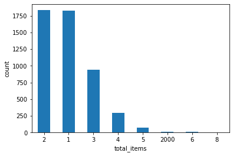

```python
# Distribution of orders for different order sizes/total_items

fig1 = df.total_items.value_counts().plot.bar(rot = 1)
fig1.set_xlabel('total_items')
fig1.set_ylabel('count')
```

It's likely that these excessively large transactions (2000) are driving up the AOV.

```python
# All orders with order_amount of 2000

df[df.total_items == 2000].sort_values('created_at', ascending = True)
```

|  | order_id | shop_id | user_id | order_amount | total_items | payment_method | created_at | item_price |
| --- | --- | --- | --- | --- | --- | --- | --- | --- |
| 520 | 521 | 42 | 607 | 704000.0 | 2000 | credit_card | 2017-03-02 04:00:00 | 352.0 |
| 4646 | 4647 | 42 | 607 | 704000.0 | 2000 | credit_card | 2017-03-02 04:00:00 | 352.0 |
| 60 | 61 | 42 | 607 | 704000.0 | 2000 | credit_card | 2017-03-04 04:00:00 | 352.0 |
| 15 | 16 | 42 | 607 | 704000.0 | 2000 | credit_card | 2017-03-07 04:00:00 | 352.0 |
| 2297 | 2298 | 42 | 607 | 704000.0 | 2000 | credit_card | 2017-03-07 04:00:00 | 352.0 |
| 1436 | 1437 | 42 | 607 | 704000.0 | 2000 | credit_card | 2017-03-11 04:00:00 | 352.0 |
| 2153 | 2154 | 42 | 607 | 704000.0 | 2000 | credit_card | 2017-03-12 04:00:00 | 352.0 |
| 1362 | 1363 | 42 | 607 | 704000.0 | 2000 | credit_card | 2017-03-15 04:00:00 | 352.0 |
| 1602 | 1603 | 42 | 607 | 704000.0 | 2000 | credit_card | 2017-03-17 04:00:00 | 352.0 |
| 1562 | 1563 | 42 | 607 | 704000.0 | 2000 | credit_card | 2017-03-19 04:00:00 | 352.0 |
| 4868 | 4869 | 42 | 607 | 704000.0 | 2000 | credit_card | 2017-03-22 04:00:00 | 352.0 |
| 3332 | 3333 | 42 | 607 | 704000.0 | 2000 | credit_card | 2017-03-24 04:00:00 | 352.0 |
| 1104 | 1105 | 42 | 607 | 704000.0 | 2000 | credit_card | 2017-03-24 04:00:00 | 352.0 |
| 4882 | 4883 | 42 | 607 | 704000.0 | 2000 | credit_card | 2017-03-25 04:00:00 | 352.0 |
| 2835 | 2836 | 42 | 607 | 704000.0 | 2000 | credit_card | 2017-03-28 04:00:00 | 352.0 |
| 2969 | 2970 | 42 | 607 | 704000.0 | 2000 | credit_card | 2017-03-28 04:00:00 | 352.0 |
| 4056 | 4057 | 42 | 607 | 704000.0 | 2000 | credit_card | 2017-03-28 04:00:00 | 352.0 |

```python
# Average order amount for each shop (lowest 5)
df.groupby('shop_id')[['order_amount']].mean().sort_values('order_amount', ascending = True).head()
```

| shop_id | order_amount |
| --- | --- |
| 92 | 162.857143 |
| 2 | 174.327273 |
| 32 | 189.976190 |
| 100 | 213.675000 |
| 53 | 214.117647 |

```python
# 5 shops based on LEAST total revenue
df.filter(['shop_id', 'order_amount'])\
        .groupby('shop_id')\
        .sum('order_amount')\
        .sort_values('order_amount', ascending = True)\
        .head(5)
```

| shop_id | order_amount |
| --- | --- |
| 92 | 6840.0 |
| 32 | 7979.0 |
| 56 | 8073.0 |
| 100 | 8547.0 |
| 2 | 9588.0 |

```python
# Average order amount for each shop (highest 5)
df.groupby('shop_id')[['order_amount']].mean().sort_values('order_amount', ascending = False).head()
```

| shop_id | order_amount |
| --- | --- |
| 42 | 235101.490196 |
| 78 | 49213.043478 |
| 50 | 403.545455 |
| 90 | 403.224490 |
| 38 | 390.857143 |

```python
# Top 5 shops based on MOST total revenue
df.filter(['shop_id', 'order_amount'])\
        .groupby('shop_id')\
        .sum('order_amount')\
        .sort_values('order_amount', ascending = False)\
        .head(5)
```

| shop_id | order_amount |
| --- | --- |
| 42 | 11990176.0 |
| 78 | 2263800.0 |
| 89 | 23128.0 |
| 81 | 22656.0 |
| 6 | 22627.0 |

**Interesting observation**: We see some inconsistency in the top 5 and the bottom 5 shops based on their average order amount and total revenue.

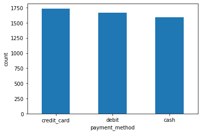

```python
# Distribution of payment_method
# No imbalance

fig2 = df.payment_method.value_counts().plot.bar(rot = 0)
fig2.set_xlabel('payment_method')
fig2.set_ylabel('count')
```

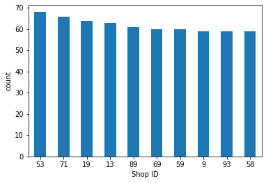

```python
# Distribution of number of orders from the top 10 Shops
# No imbalance

fig3 = df.shop_id.value_counts()[0:10].plot.bar(rot = 1)
fig3.set_xlabel('Shop ID')
fig3.set_ylabel('count')
```

```python
# Top 5 most expensive orders
df.filter(['order_id', 'order_amount'])\
        .groupby('order_id')\
        .sum('order_amount')\
        .sort_values('order_amount', ascending = False)\
        .head(5)
```

| order_id | order_amount |
| --- | --- |
| 2154 | 704000.0 |
| 3333 | 704000.0 |
| 521 | 704000.0 |
| 1603 | 704000.0 |
| 61 | 704000.0 |

```python
# 5 least expensive orders
df.filter(['order_id', 'order_amount'])\
        .groupby('order_id')\
        .sum('order_amount')\
        .sort_values('order_amount', ascending = True)\
        .head(5)
```

| order_id | order_amount |
| --- | --- |
| 159 | 90.0 |
| 3872 | 90.0 |
| 4761 | 90.0 |
| 4924 | 90.0 |
| 4933 | 90.0 |

```python
# Order history of shop 78
df[df.shop_id == 78].sort_values('order_amount',ascending = False)['order_amount'].value_counts()
```

```
25725.0     19
51450.0     16
77175.0      9
154350.0     1
102900.0     1
Name: order_amount, dtype: int64
```

```python
# Order history of shop 42
df[df.shop_id == 42].sort_values('order_amount',ascending = False)['order_amount'].value_counts()
```

```
704000.0    17
352.0       15
704.0       13
1056.0       3
1408.0       2
1760.0       1
Name: order_amount, dtype: int64
```

```python
new_df = df.groupby(['total_items']).agg({'order_amount': ['mean','max']})
new_df.columns = new_df.columns.droplevel(0)
new_df = new_df.reset_index()
new_df = new_df.rename(columns = {'mean': 'avg_order_amt',
                        'max' : 'max_order_amt'})

new_df['per_item_amt'] = new_df.max_order_amt/new_df.total_items
new_df
```

|  | total_items | avg_order_amt | max_order_amt | per_item_amt |
| --- | --- | --- | --- | --- |
| 0 | 1 | 417.364481 | 25725.0 | 25725.0 |
| 1 | 2 | 750.215066 | 51450.0 | 25725.0 |
| 2 | 3 | 1191.076514 | 77175.0 | 25725.0 |
| 3 | 4 | 947.686007 | 102900.0 | 25725.0 |
| 4 | 5 | 759.350649 | 1760.0 | 352.0 |
| 5 | 6 | 17940.000000 | 154350.0 | 25725.0 |
| 6 | 8 | 1064.000000 | 1064.0 | 133.0 |
| 7 | 2000 | 704000.000000 | 704000.0 | 352.0 |

Based on the df above, we see some of these max_order_amt are way above the average. We would never expect an average pair of shoes to cost 25725. This in addition to the duplicate transactions questions the correctness of these entries.

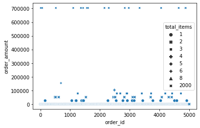

```python
sns.scatterplot(data=df, x="order_id", y="order_amount",
                style="total_items",palette="deep")

# Here every point is one transaction
```

After a thorough exploration, we can say that the best option would be to use median as a metric.

```python
df.order_amount.median()
```

```
284.0
```

### **Question 2**

For this question you’ll need to use SQL. Follow this link (https://www.w3schools.com/SQL/TRYSQL.ASP?FILENAME=TRYSQL_SELECT_ALL) to access the data set required for the challenge. Please use queries to answer the following questions. Paste your queries along with your final numerical answers below.

(i) How many orders were shipped by Speedy Express in total?

**Answer**: 54 orders were shipped by Speedy Express in total

```
SELECT o.OrderID, o.ShipperID, s.ShipperID, s.ShipperName, COUNT(*) FROM Orders o
LEFT JOIN Shippers s ON o.ShipperID = s.ShipperID
WHERE s.ShipperName = 'Speedy Express'
```

(ii) What is the last name of the employee with the most orders?

**Answer**: Peacock is the last name of the employee with the most orders, about 40

```
SELECT e.LastName, COUNT(DISTINCT(o.OrderID)) AS total_orders FROM Employees e
LEFT JOIN Orders o
ON e.EmployeeID =  o.EmployeeID
GROUP BY e.LastName
ORDER BY  total_orders DESC
LIMIT 1
```

(iii) What product was ordered the most by customers in Germany?

**Answer**: Camembert Pierrot was the product ordered the most by customers in Germany.

```
WITH ProductQuantity AS (
    SELECT Orders.OrderID, Products.ProductName, OrderDetails.Quantity
    FROM OrderDetails, Orders
    JOIN Customers ON Customers.CustomerID = Orders.CustomerID
    JOIN Products ON OrderDetails.ProductID=Products.ProductID
    WHERE Country =='Germany'
),

ProductOrders as (
    SELECT ProductName, Quantity, COUNT(*) as 'Orders'
    FROM ProductQuantity
    GROUP BY ProductName
)

SELECT ProductName, Quantity, Orders, (Orders*Quantity) AS TotalQuantityOrdered
FROM ProductOrders
ORDER BY TotalQuantityOrdered DESC
LIMIT 1;
```

| ProductName | Quantity | Orders | TotalQuantityOrdered |
| --- | --- | --- | --- |
| Camembert Pierrot | 40 | 300 | 12000 |